# Exploring Disney movies from 1937 to 2017 gross profits

**Analysis by: Lilee Yang**

# INTRODUCTION

[figure not shown]

Disney has been one of the most well known companies in the world with its nostalgic movies. What started as a dream, today it is worth about 168.45 billion! Lets go back in time and take a look at movies from 1937 to 2016 and their gross profits.

°o° Which movies genres have the greatest profits in the years?

°o° How has Disney movies progressed in popularity?

°o° What season is the best time for movies to come out?

# Needed packages

```r
library(tidyverse)
library(dplyr)
library(ggplot2)
library(lubridate)
```

# Data set

For this analysis I am using a data set created by Dr. Sanchez-Aries. This data set displays the sequence of movies created by Disney with many variables and columns.

```r
disney_movies <- read.csv("/cloud/project/data/disneymovie_data.csv" , header = TRUE)
disney_movies
```

| movie_title | release_date | genre | MPAA_rating | total_gross | inflation_adjusted_gross |
| --- | --- | --- | --- | --- | --- |
| Snow White and the Seven Dwarfs | Dec 21, 1937 | Musical | G | 184925485 | 5228953251 |
| Pinocchio | Feb 9, 1940 | Adventure | G | 84300000 | 2188229052 |
| Fantasia | Nov 13, 1940 | Musical | G | 83320000 | 2187090808 |
| Song of the South | Nov 12, 1946 | Adventure | G | 65000000 | 1078510579 |
| Cinderella | Feb 15, 1950 | Drama | G | 85000000 | 920608730 |
| 20,000 Leagues Under the Sea | Dec 23, 1954 | Adventure | G | 28200000 | 528279994 |
| Lady and the Tramp | Jun 22, 1955 | Drama | G | 93600000 | 1236035515 |
| Sleeping Beauty | Jan 29, 1959 | Drama | G | 9464608 | 21505832 |
| 101 Dalmatians | Jan 25, 1961 | Comedy | G | 153000000 | 1362870985 |
| The Absent Minded Professor | Mar 16, 1961 | Comedy | G | 25381407 | 310094574 |

[output cut: 568 more lines]

# Data Exploration

As we dive into this data set, lets take a glance of what it is.

```r
summary(disney_movies)
```

```
 movie_title        release_date          genre           MPAA_rating         total_gross        inflation_adjusted_gross
 Length:578         Length:578         Length:578         Length:578         Min.   :2.815e+03   Min.   :2.984e+03
 Class :character   Class :character   Class :character   Class :character   1st Qu.:1.292e+07   1st Qu.:2.340e+07
 Mode  :character   Mode  :character   Mode  :character   Mode  :character   Median :3.068e+07   Median :5.530e+07
                                                                             Mean   :6.755e+07   Mean   :1.192e+08
                                                                             3rd Qu.:7.576e+07   3rd Qu.:1.192e+08
                                                                             Max.   :1.730e+09   Max.   :5.229e+09
```

## Univarient Exploration

Before answering the questions about this data set let’s explore the possibilities in store. A deconstruction of individual aspects of this data set will help us understand the capabilities in each component.

### Genre

In this data set there are a variety of factors that influence the growth of Disney today. From the 578 movies, what is the distribution of movie from each genre?

```r
disney_movies %>%
  group_by(genre)%>%
  count()
```

| genre | n |
| --- | --- |
| Action | 41 |
| Adventure | 132 |
| Black Comedy | 3 |
| Comedy | 187 |
| Concert/Performance | 2 |
| Documentary | 17 |
| Drama | 116 |
| Horror | 6 |
| Musical | 17 |
| Romantic Comedy | 24 |

[output cut: 2 more lines]

The statistical breakdown reveals that Disney’s cinematic portfolio has primarily comprised of comedy and adventure genres. This strategic emphasis on these genres has evidently contributed to the creation of enduring classics, cherished by audiences through generations. The resonance of these timeless movies display crafting narratives that captivate audiences and earning a lasting place in the realm of beloved cinematic experiences.

## TOP MOVIES

**TOP TOTAL GROSS**

Examining the top ten movie gross offers an understanding for key cinematic productions that have significantly contributed to Disney’s prominence. This exploration aims to distill insights into the films that have played a pivotal role in shaping and Disney’s popularity within the industry.

```r
top_ten_movies <-disney_movies %>%
  arrange(desc(total_gross)) %>%
    slice(1:10)
print(top_ten_movies)
```

| movie_title | release_date | genre | MPAA_rating | total_gross | inflation_adjusted_gross |
| --- | --- | --- | --- | --- | --- |
| National Treasure | Nov 19, 2004 | Adventure | PG | 1730005002 | 234069353 |
| Star Wars Ep. VII: The Force Awakens | Dec 18, 2015 | Adventure | PG-13 | 936662225 | 936662225 |
| The Avengers | May 4, 2012 | Action | PG-13 | 623279547 | 660081224 |
| Rogue One: A Star Wars Story | Dec 16, 2016 | Adventure | PG-13 | 529483936 | 529483936 |
| Finding Dory | Jun 17, 2016 | Adventure | PG | 486295561 | 486295561 |
| Avengers: Age of Ultron | May 1, 2015 | Action | PG-13 | 459005868 | 459005868 |
| Pirates of the Caribbean: Dead Man’… | Jul 7, 2006 | Adventure | PG-13 | 423315812 | 544817142 |
| The Lion King | Jun 15, 1994 | Adventure | G | 422780140 | 761640898 |
| Toy Story 3 | Jun 18, 2010 | Adventure | G | 415004880 | 443408255 |
| Iron Man 3 | May 3, 2013 | Action | PG-13 | 408992272 | 424084233 |

```r
NA
```

**TOP INFLATED GROSS (with 2016 rate)**

Estimating the top 10 movies from an inflated rate can reflect how films that were previously made would compare in the year 2016. This could reveal alternative rankings and offer the evolving economics.

```r
top_ten_inflated_movies <- disney_movies %>%
  arrange(desc(inflation_adjusted_gross)) %>%
  slice(1:10)

print(top_ten_inflated_movies)
```

| movie_title | release_date | genre | MPAA_rating | total_gross | inflation_adjusted_gross |
| --- | --- | --- | --- | --- | --- |
| Snow White and the Seven Dwarfs | Dec 21, 1937 | Musical | G | 184925485 | 5228953251 |
| Pinocchio | Feb 9, 1940 | Adventure | G | 84300000 | 2188229052 |
| Fantasia | Nov 13, 1940 | Musical | G | 83320000 | 2187090808 |
| 101 Dalmatians | Jan 25, 1961 | Comedy | G | 153000000 | 1362870985 |
| Lady and the Tramp | Jun 22, 1955 | Drama | G | 93600000 | 1236035515 |
| Song of the South | Nov 12, 1946 | Adventure | G | 65000000 | 1078510579 |
| Star Wars Ep. VII: The Force Awakens | Dec 18, 2015 | Adventure | PG-13 | 936662225 | 936662225 |
| Cinderella | Feb 15, 1950 | Drama | G | 85000000 | 920608730 |
| The Jungle Book | Oct 18, 1967 | Musical | Not Rated | 141843000 | 789612346 |
| The Lion King | Jun 15, 1994 | Adventure | G | 422780140 | 761640898 |

The observation that some of the top movies are well loved classics that displays Disney’s remarkable success with its early films. This popularity is an indication to the timeless appeal and cultural impact of these cinematic treasures. It reaffirms Disney’s skills in creating narratives that resonate across generations, marking a noteworthy achievement in cinematic history.

## Audience

The Motion Picture Association of America (MPAA) rating system serves as a structure for evaluating and categorizing movies based on their content, catering to diverse audience sensitivities. This criterion significantly influences the cinematic production landscape within the industry.In our examination of major entities like Warner Brothers, A24, and 20th Century, a trend emerges where a proportion of their cinematic are tailored for adult audiences. Shifting our focus to Disney, a comprehensive analysis of their MPAA ratings offers valuable insights into the strategic choices governing the content produced by this renowned cinematic company.

```r
disney_movies %>%
  group_by(MPAA_rating)%>%
  count()
```

| MPAA_rating | n |
| --- | --- |
| G | 109 |
| Not Rated | 3 |
| PG | 208 |
| PG-13 | 151 |
| R | 107 |

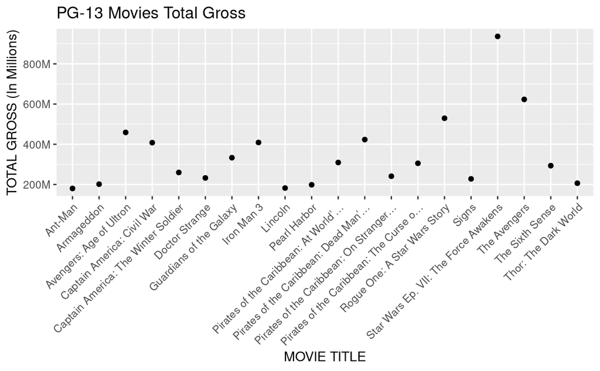

```r
  filter(disney_movies, MPAA_rating == "PG-13") %>%
  arrange(desc(total_gross)) %>%
  slice(1:20) %>%
   ggplot() +
  geom_point(aes(x = movie_title, y =total_gross))+
  labs(
    title = "PG-13 Movies Total Gross",
    x = "MOVIE TITLE",
    y = "TOTAL GROSS (In Millions)") +
  theme(axis.text.x = element_text(angle = 45, hjust = 1))+
  scale_y_continuous(labels = scales::label_number_si(scale = 1e-6, suffix = "M"))
```

```r
NA
```

## Multivarient Exploration

In the subsequent phase of our exploration, we will take a look on a multifaceted level to uncover deeper layers and extract additional insights.

### Genre throughout the years

To grasp the data visually in the evolution of Disney a graphical representation is ideal. By creating a visual we can see the progression in genres over the years and Disney’s strategic shift of movies.

```r
year_release <- disney_movies %>%
  mutate(year_release = year(mdy(release_date)))

year_release
```

| movie_title | release_date | genre | MPAA_rating | total_gross | inflation_adjusted_gross | year_release |
| --- | --- | --- | --- | --- | --- | --- |
| Snow White and the Seven Dwarfs | Dec 21, 1937 | Musical | G | 184925485 | 5228953251 | 1937 |
| Pinocchio | Feb 9, 1940 | Adventure | G | 84300000 | 2188229052 | 1940 |
| Fantasia | Nov 13, 1940 | Musical | G | 83320000 | 2187090808 | 1940 |
| Song of the South | Nov 12, 1946 | Adventure | G | 65000000 | 1078510579 | 1946 |
| Cinderella | Feb 15, 1950 | Drama | G | 85000000 | 920608730 | 1950 |
| 20,000 Leagues Under the Sea | Dec 23, 1954 | Adventure | G | 28200000 | 528279994 | 1954 |
| Lady and the Tramp | Jun 22, 1955 | Drama | G | 93600000 | 1236035515 | 1955 |
| Sleeping Beauty | Jan 29, 1959 | Drama | G | 9464608 | 21505832 | 1959 |
| 101 Dalmatians | Jan 25, 1961 | Comedy | G | 153000000 | 1362870985 | 1961 |
| The Absent Minded Professor | Mar 16, 1961 | Comedy | G | 25381407 | 310094574 | 1961 |

[output cut: 568 more lines]

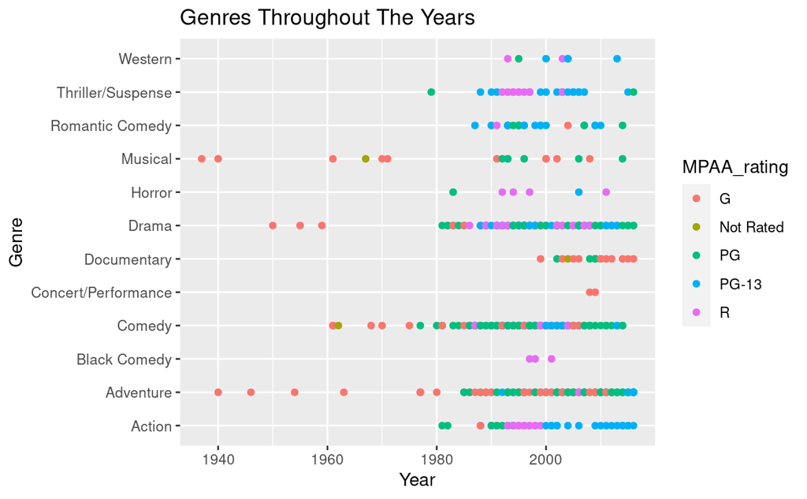

```r
  ggplot(year_release) +
  geom_point(aes(x = year_release, y =genre, color=MPAA_rating))+
  labs(
    title = "Genres Throughout The Years",
    x = "Year",
    y = "Genre")
```

## Audience shifts

The early classics are primary geared towards a younger audience, but as the years go by lets take a look at how it changes.

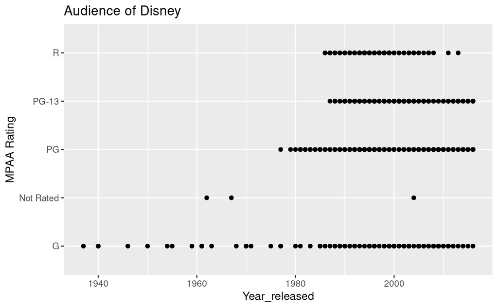

```r
  ggplot(year_release) +
  geom_point(aes(x =year_release, y =MPAA_rating))+
  labs(
    title = "Audience of Disney",
    x = "Year_released",
    y = "MPAA Rating")
```

This observation highlights that during Disney’s early years, the focus was on creating movies with widespread audience appeal. As time has advanced, Disney has shown a dynamic evolution, expanding its cinematic repertoire to include a diverse array of genres that effectively cater to audiences of all age groups that keep them appealing for adults as well.

# DATA ANALYSIS

After completing an exploration of movies, the previous asked questions can be answered from the data.

## What movie genres generated the greatest gross profit?

In the realm of cinematic preferences, individuals often gravitate towards specific genres that resonate with their personal preferences Whether it be the action-packed superhero narratives or the simple joy derived from lighthearted comedies, individual liking plays an essential role in shaping cinematic preferences.

Examining the popularity trends across different genres throughout the years becomes instrumental in understanding Disney’s fondness towards certain genres. The appeal of specific genres may serve as a factor for Disney’s continued production and preferences of their audience base.

```r
total_gross_by_genre <- disney_movies %>%
  group_by(genre) %>%
  summarise(total_gross_by_genre = sum(total_gross, na.rm = TRUE))

print(total_gross_by_genre)
```

| genre | total_gross_by_genre |
| --- | --- |
| Action | 4191557865 |
| Adventure | 18011762299 |
| Black Comedy | 97543212 |
| Comedy | 8146366723 |
| Concert/Performance | 103456466 |
| Documentary | 180914747 |
| Drama | 4104054117 |
| Horror | 87068872 |
| Musical | 1159890507 |
| Romantic Comedy | 1155425737 |

[output cut: 2 more lines]

```r
NA
```

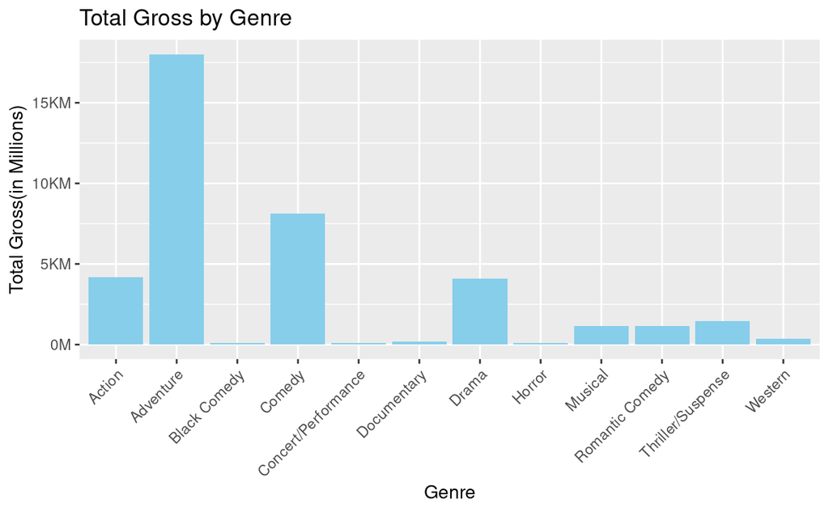

```r
ggplot(total_gross_by_genre, aes(x = genre, y = total_gross_by_genre)) +
  geom_histogram(stat = "identity", fill = "skyblue") +
  labs(title = "Total Gross by Genre", x = "Genre", y = "Total Gross(in Millions)")+
theme(axis.text.x = element_text(angle = 45, hjust = 1)) +
  scale_y_continuous(labels = scales::label_number_si(scale = 1e-6, suffix = "M"))
```

The analysis indicates that adventure movies stand out as the primary contributors to the highest overall gross profit. Noteworthy titles such as “Star Wars: The Force Awakens,” “The Lion King,” and “Toy Story” display this trend. This profit generation can potentially contribute to the widespread appeal of narratives featuring heroes embarking on adventures through life, associated well with younger audiences in both animated and cinematic forms. This factor likely contributes significantly to the profitability and recognition of these films.

## How has disney movies progressed in popularity?

In Disney’s remarkable success, we turn our to the evolving landscape of total gross over the years. The ascent in total gross often displays the popularity of a company in a growing affinity for their cinematic offerings. This analytical approach allows us to discern the years marked by success as well as those where the company faced challenges, thereby providing a comprehensive overview of Disney’s dynamic journey.

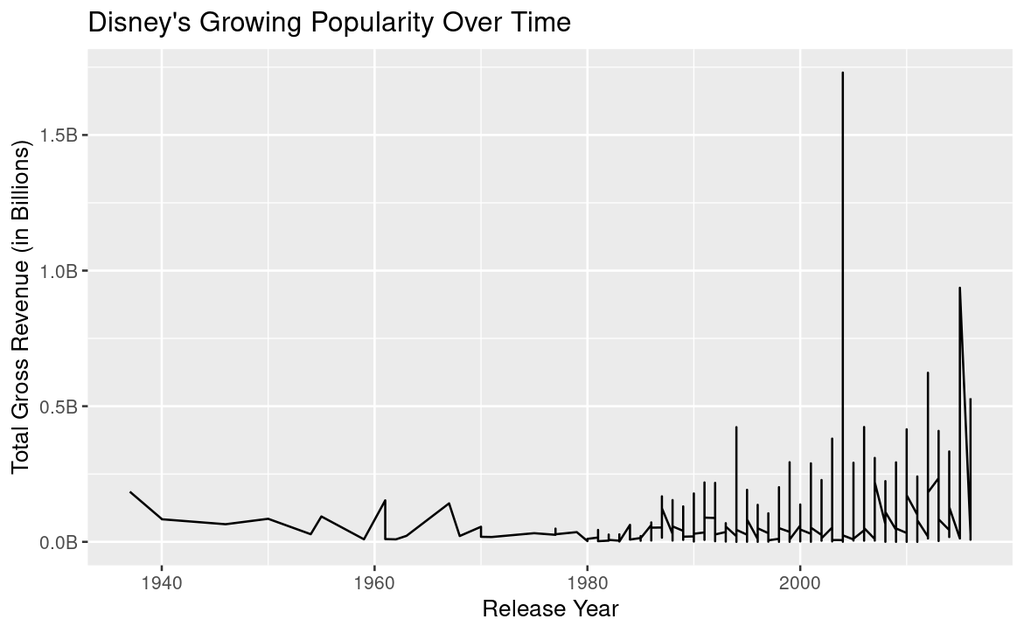

```r
ggplot(year_release, aes(x = year_release, y = total_gross)) +
  geom_line() +
  labs(title = "Disney's Growing Popularity Over Time",
       x = "Release Year",
       y = "Total Gross Revenue (in Billions)") +
  theme_grey() +
  scale_y_continuous(labels = scales::label_number_si(scale = 1e-9, suffix = "B"))
```

## What Seasons of the year is best for movies to come out ?

The season of a movie’s release may have considerable influence over its potential for popularity. For instance, the summer months, where children are on break, might offer a conducive environment for heightened profitability. However, it remains whether this factor sways the drive watch these films. An exploration of this aspect will provide insights into the fluctuation between release timing and audience engagement.

```r
seasonal_counts <- disney_movies %>%
  mutate(season = case_when(
    month(mdy(release_date)) %in% c(3, 4, 5) ~ "Spring",
    month(mdy(release_date)) %in% c(6, 7, 8) ~ "Summer",
    month(mdy(release_date)) %in% c(9, 10, 11) ~ "Fall",
    TRUE ~ "Winter"
  )) %>%
  group_by(season) %>%
  summarise(count = n())

print(seasonal_counts)
```

| season | count |
| --- | --- |
| Fall | 152 |
| Spring | 152 |
| Summer | 143 |
| Winter | 131 |

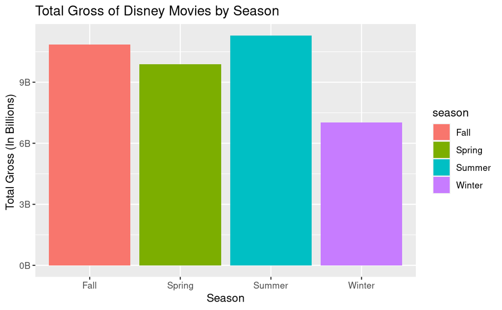

```r
seasonal_gross <- disney_movies %>%
  mutate(season = case_when(
    month(mdy(release_date)) %in% c(3, 4, 5) ~ "Spring",
    month(mdy(release_date)) %in% c(6, 7, 8) ~ "Summer",
    month(mdy(release_date)) %in% c(9, 10, 11) ~ "Fall",
    TRUE ~ "Winter"
  )) %>%
  group_by(season) %>%
  summarise(total_gross = sum(total_gross, na.rm = TRUE))


ggplot(seasonal_gross, aes(x = season, y = total_gross, fill = season)) +
  geom_bar(stat = "identity") +
  labs(title = "Total Gross of Disney Movies by Season",
       x = "Season",
       y = "Total Gross (In Billions) ") +
    scale_y_continuous(labels = scales::label_number_si(scale = 1e-9, suffix = "B"))
```

Summer is one of the best times of the year for kids and this could be a reason for it to have the largest gross.

```r
disney_movies %>%
  mutate(season = case_when(
    month(mdy(release_date)) %in% c(3, 4, 5) ~ "Spring",
    month(mdy(release_date)) %in% c(6, 7, 8) ~ "Summer",
    month(mdy(release_date)) %in% c(9, 10, 11) ~ "Fall",
    TRUE ~ "Winter"
  ))
```

| movie_title | release_date | genre | MPAA_rating | total_gross | inflation_adjusted_gross | season |
| --- | --- | --- | --- | --- | --- | --- |
| Snow White and the Seven Dwarfs | Dec 21, 1937 | Musical | G | 184925485 | 5228953251 | Winter |
| Pinocchio | Feb 9, 1940 | Adventure | G | 84300000 | 2188229052 | Winter |
| Fantasia | Nov 13, 1940 | Musical | G | 83320000 | 2187090808 | Fall |
| Song of the South | Nov 12, 1946 | Adventure | G | 65000000 | 1078510579 | Fall |
| Cinderella | Feb 15, 1950 | Drama | G | 85000000 | 920608730 | Winter |
| 20,000 Leagues Under the Sea | Dec 23, 1954 | Adventure | G | 28200000 | 528279994 | Winter |
| Lady and the Tramp | Jun 22, 1955 | Drama | G | 93600000 | 1236035515 | Summer |
| Sleeping Beauty | Jan 29, 1959 | Drama | G | 9464608 | 21505832 | Winter |
| 101 Dalmatians | Jan 25, 1961 | Comedy | G | 153000000 | 1362870985 | Winter |
| The Absent Minded Professor | Mar 16, 1961 | Comedy | G | 25381407 | 310094574 | Spring |

[output cut: 568 more lines]

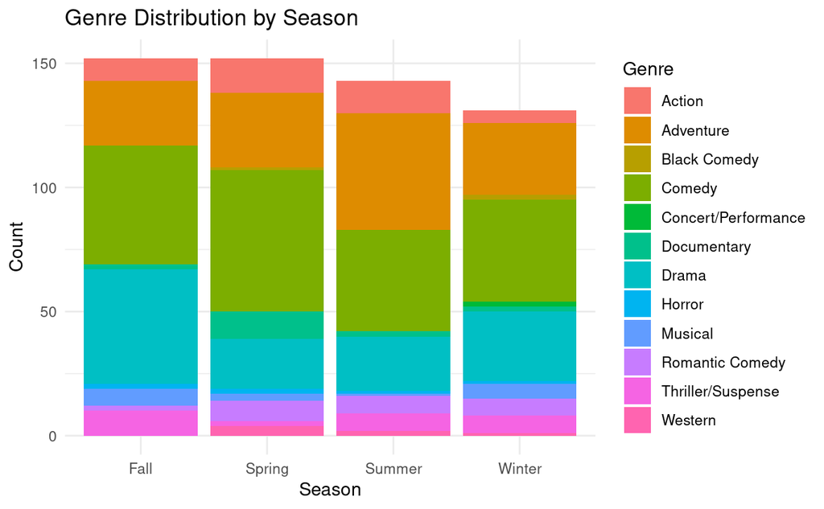

```r
ggplot(disney_movies, aes(x = season, fill = genre)) +
  geom_bar(position = "stack") +
  labs(title = "Genre Distribution by Season",
       x = "Season",
       y = "Count",
       fill = "Genre") +
  theme_minimal()
```

```r
NA
NA
```

# Conclusion

[figure not shown]

Through a comprehensive exploration of the data set, it becomes evident that things change over time. Notably, the genre of a movie emerges as a significant factor influencing its overall financial performance. The analytically visualizations crafted during this investigation display trends over the years, unveiling the evolution of cinematic diversity within the data set. The study of Disney cinematic has proven to offering valuable insights into the company’s intricate dynamics that make it a what it is today. This analysis has cultivated a deeper understanding of the underlying patterns governing the flexibility between time, genre, and financial success in the realm of Disney movies.The acquired proficiency in utilizing analytically tools and methods from this course demonstrates versatility. These skills have provided insights for future explorations of diverse data sets, underscoring the enduring impact of this learning experience.